# HW02: Colgate vs Crest

Alejandro José Gómez Rivas

14/11/2021

## Lectura de data.xlsx

Como primer paso, separo el conjunto de datos de Colgate y Crest en series temporales, y para aplicar las muestras de train y de test del modelo, especifico la fecha del comienzo y del final. Al tener una frecuencia semanal, en frequency coloco un valor de 52.18 ya que es el número de semanas que tiene aproximadamente un año convencional.

```
## Time Series:
## Start = c(1958, 1)
## End = c(1962, 52)
## Frequency = 52
##   [1] 0.424 0.482 0.428 0.397 0.352 0.342 0.434 0.445 0.428 0.395 0.354 0.497
##  [13] 0.425 0.401 0.363 0.341 0.464 0.431 0.405 0.460 0.410 0.423 0.310 0.413
##  [25] 0.411 0.452 0.405 0.290 0.342 0.311 0.327 0.413 0.400 0.380 0.371 0.344
##  [37] 0.345 0.363 0.392 0.379 0.349 0.337 0.235 0.250 0.360 0.282 0.257 0.345
##  [49] 0.344 0.358 0.322 0.332 0.315 0.316 0.341 0.387 0.402 0.347 0.414 0.426
##  [61] 0.322 0.372 0.381 0.339 0.405 0.304 0.439 0.336 0.405 0.359 0.379 0.303
##  [73] 0.340 0.312 0.291 0.259 0.342 0.458 0.275 0.340 0.385 0.338 0.370 0.290
##  [85] 0.325 0.337 0.338 0.323 0.357 0.381 0.371 0.294 0.384 0.286 0.335 0.310
##  [97] 0.304 0.305 0.403 0.365 0.305 0.172 0.321 0.343 0.354 0.316 0.292 0.305
## [109] 0.294 0.289 0.301 0.304 0.306 0.405 0.344 0.353 0.383 0.349 0.374 0.411
## [121] 0.287 0.420 0.470 0.354 0.392 0.421 0.435 0.424 0.344 0.369 0.364 0.386
## [133] 0.406 0.439 0.345 0.291 0.292 0.249 0.283 0.301 0.280 0.251 0.303 0.274
## [145] 0.328 0.244 0.323 0.288 0.293 0.321 0.330 0.273 0.304 0.292 0.251 0.350
## [157] 0.302 0.306 0.272 0.296 0.265 0.364 0.284 0.330 0.351 0.336 0.383 0.214
## [169] 0.260 0.298 0.248 0.308 0.356 0.278 0.314 0.214 0.253 0.287 0.238 0.253
## [181] 0.336 0.255 0.249 0.195 0.269 0.201 0.184 0.203 0.193 0.322 0.261 0.183
## [193] 0.289 0.243 0.302 0.350 0.401 0.332 0.351 0.280 0.308 0.299 0.199 0.283
## [205] 0.333 0.233 0.296 0.267 0.253 0.239 0.155 0.247 0.201 0.266 0.290 0.231
## [217] 0.255 0.242 0.271 0.266 0.244 0.204 0.213 0.295 0.254 0.242 0.228 0.181
## [229] 0.264 0.277 0.284 0.248 0.280 0.249 0.279 0.282 0.267 0.252 0.190 0.284
## [241] 0.207 0.327 0.259 0.286 0.275 0.244 0.341 0.331 0.250 0.220 0.293 0.205
## [253] 0.254 0.268 0.211 0.203 0.271 0.290 0.323 0.253
```

```
## Time Series:
## Start = 1962.98275201227
## End = 1963.27021847451
## Frequency = 52.18
##  [1] 0.230 0.220 0.235 0.228 0.216 0.324 0.268 0.257 0.194 0.212 0.218 0.216
## [13] 0.276 0.190 0.249 0.172
```

```
## Time Series:
## Start = c(1958, 1)
## End = c(1962, 52)
## Frequency = 52
##   [1] 0.108 0.166 0.126 0.115 0.119 0.176 0.155 0.118 0.136 0.137 0.124 0.131
##  [13] 0.120 0.133 0.067 0.086 0.140 0.122 0.105 0.079 0.130 0.142 0.120 0.115
##  [25] 0.103 0.078 0.093 0.086 0.099 0.078 0.095 0.094 0.056 0.050 0.065 0.091
##  [37] 0.094 0.124 0.153 0.078 0.114 0.088 0.165 0.160 0.075 0.118 0.100 0.102
##  [49] 0.131 0.148 0.137 0.090 0.088 0.172 0.111 0.097 0.098 0.090 0.127 0.116
##  [61] 0.137 0.111 0.107 0.097 0.134 0.160 0.147 0.104 0.128 0.128 0.165 0.184
##  [73] 0.172 0.207 0.221 0.159 0.198 0.197 0.251 0.146 0.133 0.243 0.192 0.150
##  [85] 0.221 0.183 0.136 0.206 0.127 0.139 0.189 0.194 0.114 0.229 0.148 0.155
##  [97] 0.106 0.156 0.053 0.112 0.084 0.191 0.149 0.143 0.094 0.184 0.205 0.206
## [109] 0.191 0.195 0.179 0.272 0.203 0.165 0.138 0.216 0.132 0.120 0.083 0.118
## [121] 0.125 0.109 0.119 0.154 0.122 0.126 0.126 0.130 0.158 0.141 0.145 0.127
## [133] 0.171 0.152 0.211 0.309 0.242 0.380 0.362 0.328 0.359 0.352 0.322 0.333
## [145] 0.365 0.367 0.305 0.298 0.307 0.318 0.280 0.298 0.336 0.339 0.344 0.310
## [157] 0.317 0.369 0.320 0.290 0.361 0.235 0.320 0.337 0.289 0.339 0.187 0.414
## [169] 0.373 0.265 0.316 0.245 0.328 0.368 0.287 0.369 0.406 0.316 0.362 0.308
## [181] 0.286 0.420 0.299 0.383 0.354 0.418 0.425 0.445 0.408 0.282 0.410 0.425
## [193] 0.358 0.393 0.375 0.273 0.237 0.331 0.335 0.395 0.357 0.296 0.307 0.390
## [205] 0.298 0.381 0.354 0.436 0.357 0.427 0.432 0.450 0.530 0.431 0.420 0.411
## [217] 0.423 0.433 0.393 0.389 0.387 0.439 0.421 0.363 0.401 0.394 0.459 0.441
## [229] 0.388 0.373 0.385 0.314 0.347 0.408 0.341 0.361 0.414 0.380 0.274 0.352
## [241] 0.439 0.355 0.435 0.408 0.383 0.357 0.374 0.366 0.346 0.381 0.329 0.474
## [253] 0.397 0.436 0.417 0.430 0.388 0.453 0.316 0.414
```

```
## Time Series:
## Start = 1962.98275201227
## End = 1963.27021847451
## Frequency = 52.18
##  [1] 0.396 0.420 0.432 0.453 0.430 0.327 0.388 0.377 0.466 0.478 0.365 0.472
## [13] 0.399 0.391 0.473 0.384
```

Se hacen las gráficas mostrando las cuotas de mercado de Colgate y de Crest:

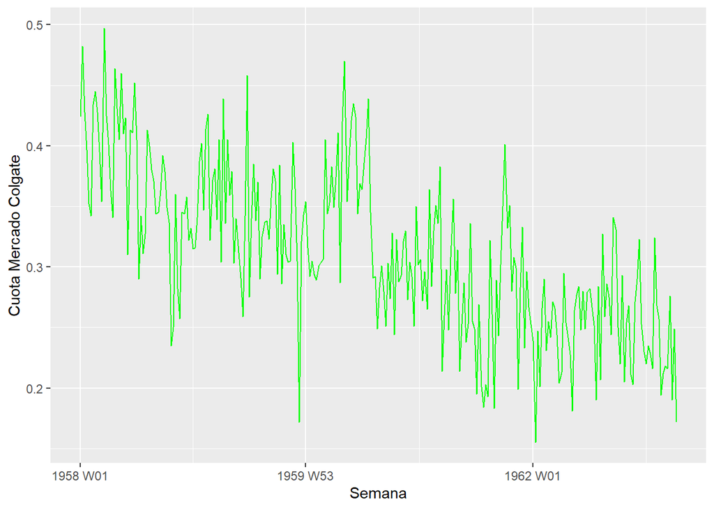

```r
ggplot(colgate_ts_tsibble)+
  geom_line(aes(x=index, y=value), colour="green")+
  ylab("Cuota Mercado Colgate")+
  xlab("Semana")
```

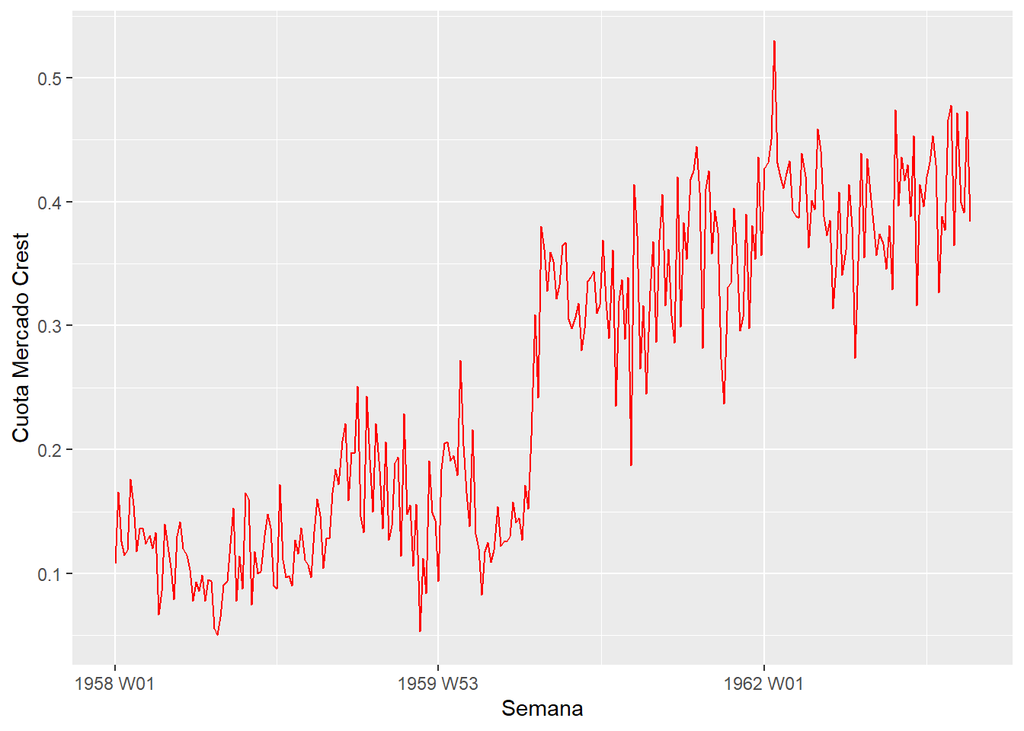

```r
ggplot(crest_ts_tsibble)+
  geom_line(aes(x=index, y=value), colour="red")+
  ylab("Cuota Mercado Crest")+
  xlab("Semana")
```

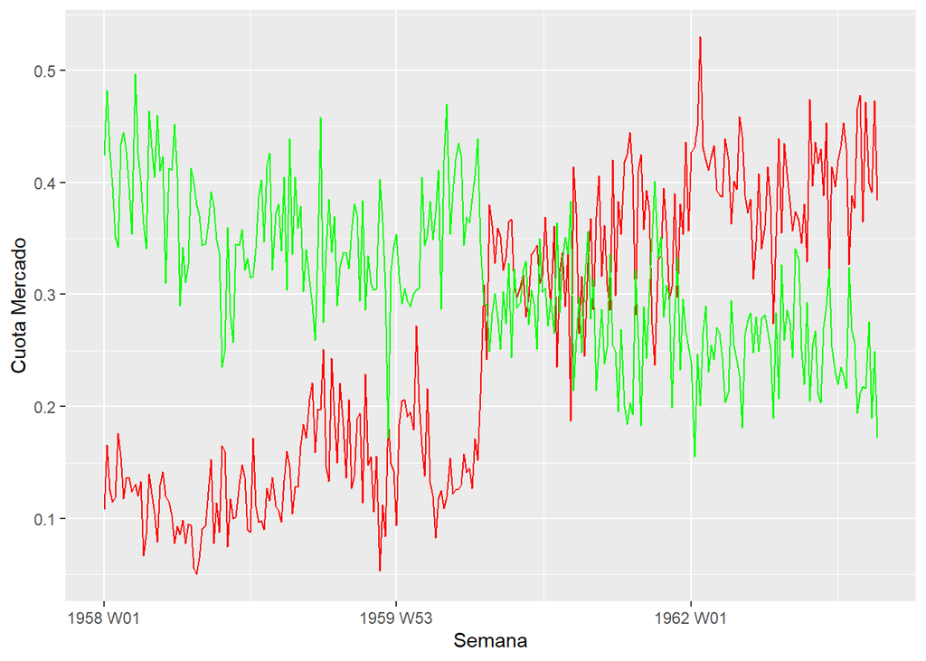

```r
ggplot(data_ts)+
  geom_line(aes(x=index, y=value), colour="red")+
  geom_line(aes(x=index, y=value_2), colour="green")+
  ylab("Cuota Mercado")+
  xlab("Semana")
```

Como aspectos a destacar al echar un vistazo a las gráficas, se puede apreciar una pronunciada cuota de mercado de Colgate al principio, por encima del 40%, pero a partir del 1 de agosto de 1960, gracias a la aprobación del Consejo de Terapéutica Dental de la ADA (American Dental Association) a Crest de P&G al catalogarla como una ayuda importante dentro del sector de higiene dental, ligado a una sólida campaña de marketing por parte de la propia marca aprovechando este hecho, aumentó significativamente su cuota de mercado, consiguiendo desbancar a Colgate.

## ARIMA

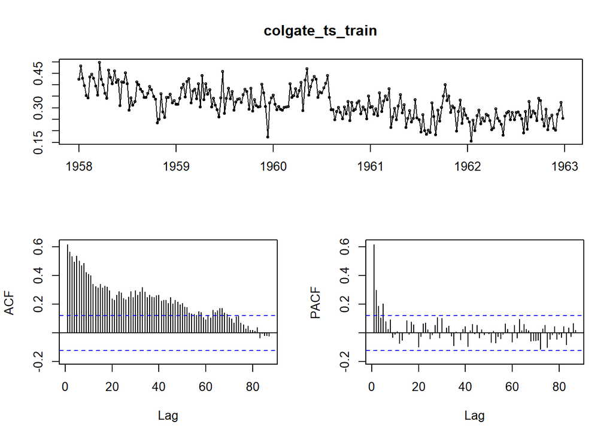

```r
tsdisplay(colgate_ts_train)
```

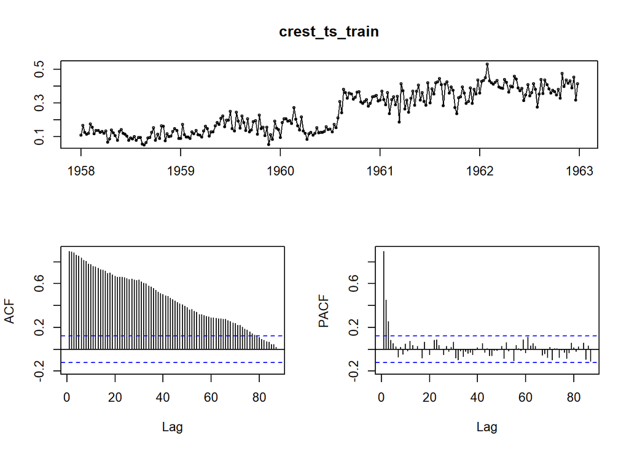

```r
tsdisplay(crest_ts_train)
```

Como se aprecian, las series no poseen ruido blanco.

A continuación, se procede a estimar ARIMA de Colgate y Crest con la función AutoARIMA y el teorema de Ljung-Box, que indicará si existe dependencia entrelos residuos estimados, o sea, si dichos residuos presentan correlación no nula.

Si la p-value es < 0.05, hay correlación entre los residuos, y si es > 0.05, no lo habrá.

```r
#ARIMA de Colgate
arima_colgate <- auto.arima(colgate_ts_train,lambda = 0)
summary(arima_colgate)
```

```
## Series: colgate_ts_train
## ARIMA(0,1,1)
## Box Cox transformation: lambda= 0
##
## Coefficients:
##           ma1
##       -0.7688
## s.e.   0.0480
##
## sigma^2 estimated as 0.02572:  log likelihood=106.6
## AIC=-209.2   AICc=-209.15   BIC=-202.08
##
## Training set error measures:
##                        ME       RMSE        MAE       MPE     MAPE      MASE
## Training set 0.0001499824 0.04794299 0.03787449 -2.139878 12.73175 0.6059918
##                    ACF1
## Training set 0.06055707
```

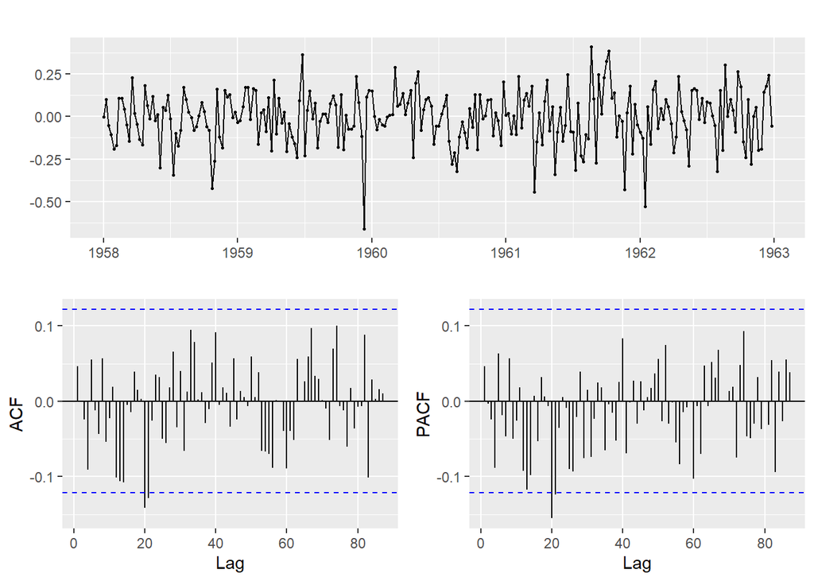

```r
#residual analysis
ggtsdisplay(arima_colgate$residuals)
```

```r
#box-Ljung Test
Box.test(arima_colgate$residuals,lag = 52, fitdf = 0, type="Lj")
```

```
##
##  Box-Ljung test
##
## data:  arima_colgate$residuals
## X-squared = 43.845, df = 52, p-value = 0.7821
```

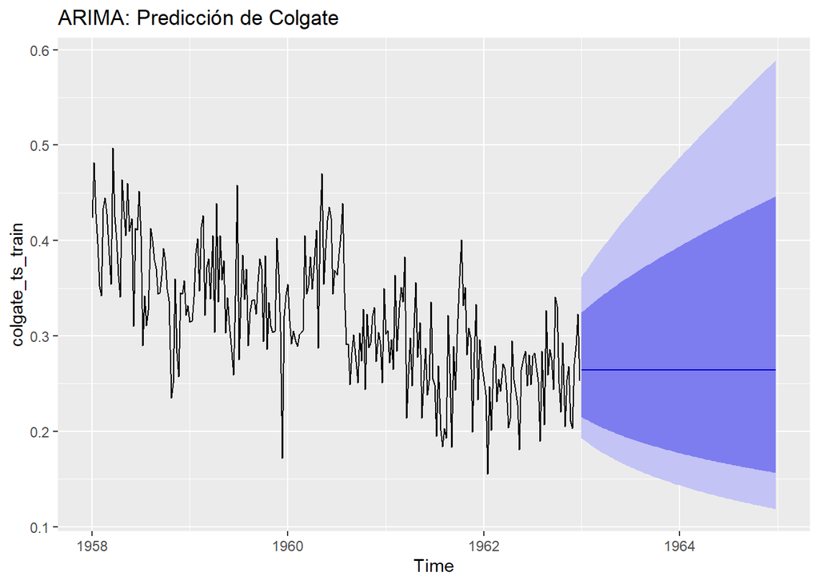

```r
# Forecast
forecast_colgate=forecast(arima_colgate)

autoplot(forecast_colgate)+ggtitle("ARIMA: Predicción de Colgate")
```

```r
print(forecast_colgate)
```

```
##          Point Forecast     Lo 80     Hi 80     Lo 95     Hi 95
## 1963.000      0.2642873 0.2151901 0.3245865 0.1930074 0.3618917
## 1963.019      0.2642873 0.2140266 0.3263509 0.1914138 0.3649047
## 1963.038      0.2642873 0.2128984 0.3280803 0.1898728 0.3678662
## 1963.058      0.2642873 0.2118028 0.3297774 0.1883805 0.3707803
## 1963.077      0.2642873 0.2107377 0.3314442 0.1869336 0.3736503
## 1963.096      0.2642873 0.2097009 0.3330829 0.1855289 0.3764793
## 1963.115      0.2642873 0.2086907 0.3346952 0.1841638 0.3792699
## 1963.135      0.2642873 0.2077055 0.3362827 0.1828358 0.3820247
## 1963.154      0.2642873 0.2067438 0.3378470 0.1815427 0.3847459
## 1963.173      0.2642873 0.2058043 0.3393894 0.1802824 0.3874354
## 1963.192      0.2642873 0.2048857 0.3409110 0.1790532 0.3900951
## 1963.212      0.2642873 0.2039870 0.3424130 0.1778535 0.3927266
## 1963.231      0.2642873 0.2031071 0.3438963 0.1766815 0.3953315
## 1963.250      0.2642873 0.2022451 0.3453620 0.1755361 0.3979112
## 1963.269      0.2642873 0.2014002 0.3468109 0.1744158 0.4004670
## 1963.288      0.2642873 0.2005716 0.3482436 0.1733195 0.4030001
## 1963.308      0.2642873 0.1997585 0.3496611 0.1722461 0.4055115
## 1963.327      0.2642873 0.1989603 0.3510640 0.1711946 0.4080023
## 1963.346      0.2642873 0.1981763 0.3524528 0.1701640 0.4104734
## 1963.365      0.2642873 0.1974059 0.3538283 0.1691534 0.4129258
## 1963.385      0.2642873 0.1966486 0.3551908 0.1681619 0.4153602
## 1963.404      0.2642873 0.1959039 0.3565411 0.1671890 0.4177775
## 1963.423      0.2642873 0.1951713 0.3578795 0.1662337 0.4201783
## 1963.442      0.2642873 0.1944503 0.3592064 0.1652954 0.4225633
## 1963.462      0.2642873 0.1937405 0.3605224 0.1643736 0.4249332
## 1963.481      0.2642873 0.1930415 0.3618278 0.1634675 0.4272886
## 1963.500      0.2642873 0.1923530 0.3631230 0.1625766 0.4296300
## 1963.519      0.2642873 0.1916745 0.3644084 0.1617004 0.4319580
## 1963.538      0.2642873 0.1910057 0.3656842 0.1608384 0.4342731
## 1963.558      0.2642873 0.1903464 0.3669509 0.1599901 0.4365757
## 1963.577      0.2642873 0.1896962 0.3682086 0.1591550 0.4388664
## 1963.596      0.2642873 0.1890548 0.3694578 0.1583328 0.4411455
## 1963.615      0.2642873 0.1884220 0.3706986 0.1575229 0.4434134
## 1963.635      0.2642873 0.1877975 0.3719314 0.1567251 0.4456706
## 1963.654      0.2642873 0.1871810 0.3731564 0.1559390 0.4479173
## 1963.673      0.2642873 0.1865724 0.3743737 0.1551642 0.4501540
## 1963.692      0.2642873 0.1859713 0.3755837 0.1544003 0.4523811
## 1963.712      0.2642873 0.1853776 0.3767865 0.1536471 0.4545987
## 1963.731      0.2642873 0.1847911 0.3779824 0.1529043 0.4568072
```

[output cut: 50 more lines]

```
## 1964.712      0.2642873 0.1614044 0.4327501 0.1243213 0.5618327
## 1964.731      0.2642873 0.1610362 0.4337395 0.1238878 0.5637986
## 1964.750      0.2642873 0.1606706 0.4347267 0.1234578 0.5657622
## 1964.769      0.2642873 0.1603074 0.4357117 0.1230313 0.5677238
## 1964.788      0.2642873 0.1599466 0.4366944 0.1226081 0.5696832
## 1964.808      0.2642873 0.1595883 0.4376749 0.1221883 0.5716406
## 1964.827      0.2642873 0.1592323 0.4386532 0.1217717 0.5735960
## 1964.846      0.2642873 0.1588788 0.4396295 0.1213584 0.5755495
## 1964.865      0.2642873 0.1585275 0.4406036 0.1209483 0.5775011
## 1964.885      0.2642873 0.1581785 0.4415758 0.1205413 0.5794509
## 1964.904      0.2642873 0.1578318 0.4425458 0.1201375 0.5813989
## 1964.923      0.2642873 0.1574872 0.4435139 0.1197366 0.5833451
## 1964.942      0.2642873 0.1571449 0.4444800 0.1193388 0.5852896
## 1964.962      0.2642873 0.1568048 0.4454442 0.1189440 0.5872325
## 1964.981      0.2642873 0.1564668 0.4464065 0.1185521 0.5891737
```

```
## Series: crest_ts_train
## ARIMA(3,1,0)(1,0,0)[52]
## Box Cox transformation: lambda= 0
##
## Coefficients:
##           ar1      ar2      ar3    sar1
##       -0.6192  -0.3722  -0.2245  0.0502
## s.e.   0.0606   0.0680   0.0610  0.0674
##
## sigma^2 estimated as 0.05158:  log likelihood=18.1
## AIC=-26.2   AICc=-25.97   BIC=-8.42
##
## Training set error measures:
##                      ME       RMSE        MAE       MPE     MAPE      MASE
## Training set 0.00459677 0.04616894 0.03540878 -1.643406 17.35163 0.3905725
##                     ACF1
## Training set -0.07847773
```

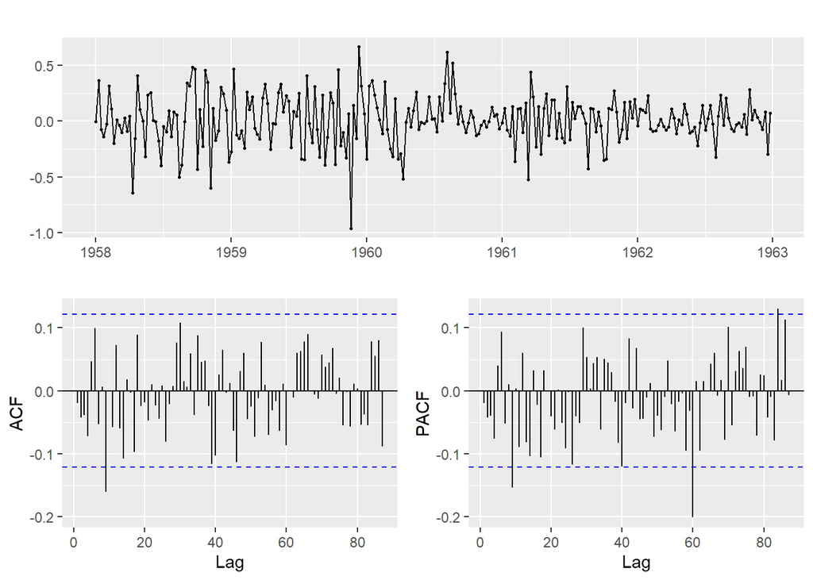

```
##
##  Box-Ljung test
##
## data:  arima_crest$residuals
## X-squared = 57.686, df = 52, p-value = 0.2731
```

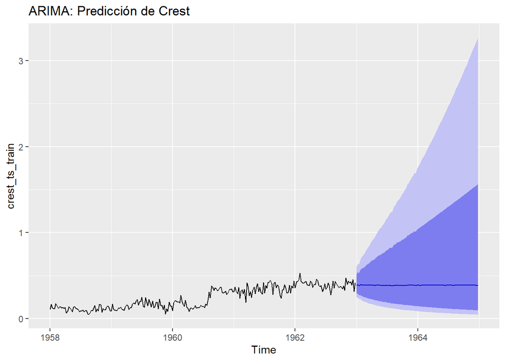

El (3, 1, 0) del ARIMA de Crest es un componente autorregresivo, y (1, 0, 0) es componente autorregresivo estacional.

## Outliers

Ahora se van a indicar los outliers que pueden aparecer en el modelo, que pueden ser de tipo AO (Additive Outlier), LS (Level Shift) y TC (Temporary Change):

```r
# Outliers Colgate
tso(y = as.ts(colgate_ts_train), types = c("AO", "LS", "TC"),discard.method = "bottom-up", tsmethod = "auto.arima", args.tsmethod = list(allowdrift = FALSE, ic = "bic"))
```

```
## Series: as.ts(colgate_ts_train)
## Regression with ARIMA(3,0,0)(1,0,0)[52] errors
##
## Coefficients:
##          ar1     ar2     ar3    sar1  intercept    AO102    LS136
##       0.2376  0.1615  0.1522  0.0307     0.3629  -0.1783  -0.0910
## s.e.  0.0619  0.0628  0.0626  0.0713     0.0087   0.0435   0.0122
##
## sigma^2 estimated as 0.002108:  log likelihood=435.5
## AIC=-855   AICc=-854.43   BIC=-826.52
##
## Outliers:
##   type ind    time  coefhat  tstat
## 1   AO 102 1959:50 -0.17828 -4.094
## 2   LS 136 1960:32 -0.09105 -7.452
```

El outlier de tipo LS da como resultado un número negativo, dentro de la semana 136, que coincide cuando el Consejo de Terapéutica Dental de la ADA recomienda a Crest. En este caso hay que realizar un modelo de intervención para este outlier, ya que existen motivos y no es atípico.

```r
# Outliers Crest
tso(y = as.ts(crest_ts_train), types = c("AO", "LS", "TC"),discard.method = "bottom-up", tsmethod = "auto.arima", args.tsmethod = list(allowdrift = FALSE, ic = "bic"))
```

```
## Series: as.ts(crest_ts_train)
## Regression with ARIMA(0,1,1) errors
##
## Coefficients:
##           ma1   LS136    AO167    TC196
##       -0.7725  0.1619  -0.1432  -0.1312
## s.e.   0.0477  0.0270   0.0387   0.0342
##
## sigma^2 estimated as 0.001712:  log likelihood=458.97
## AIC=-907.95   AICc=-907.71   BIC=-890.16
##
## Outliers:
##   type ind    time coefhat  tstat
## 1   LS 136 1960:32  0.1619  5.990
## 2   AO 167 1961:11 -0.1432 -3.701
## 3   TC 196 1961:40 -0.1312 -3.831
```

Aquí ocurre el mismo motivo que con Colgate, pero esta vez a favor de Crest. También habría que realizar un modelo de intervención al no haber datos atípicos.

## Modelo de intervención de Colgate

Como se ha comentado antes, se realiza el modelo de intervenciónl. Primero se crea un DF que coge los outliers y los convierte en dummies y, por último, se añade el componente estacional que se mencionó anteriormente al AR(3)

```r
int_data=as.ts(colgate_ts)
dummies=data.frame(
          LS6032=1*(seq(colgate_ts)>=136),
          AO5950=1*(seq(colgate_ts)==102))
mod_int=arimax(int_data,order=c(3,0,0),
               seasonal=list(order=c(1,0,0),period=52),
        xreg=dummies,
        method='ML')
mod_int
```

```
##
## Call:
## arimax(x = int_data, order = c(3, 0, 0), seasonal = list(order = c(1, 0, 0),
##     period = 52), xreg = dummies, method = "ML")
##
## Coefficients:
##          ar1     ar2     ar3    sar1  intercept   LS6032   AO5950
##       0.2455  0.1761  0.1393  0.0425     0.3626  -0.0962  -0.1777
## s.e.  0.0596  0.0612  0.0613  0.0686     0.0089   0.0122   0.0434
##
## sigma^2 estimated as 0.002049:  log likelihood = 462.44,  aic = -910.88
```

## Modelo de intervención de Crest

Se realiza el modelo de intervención una vez se han especificado los outliers en el paso anterior. Se crea un data Frame que captura los outliers y los convierte en variables dummy, en función del tipo de outlier que sea.

```r
int_data=as.ts(crest_ts)
dummies=data.frame(
          LS6032=1*(seq(colgate_ts)>=136),
          AO5950=1*(seq(colgate_ts)==167),
          TC6140=1*(seq(colgate_ts)==196))
mod_int=arimax(int_data,order=c(0,1,1),
        xreg=dummies,
        method='ML')
mod_int
```

```
##
## Call:
## arimax(x = int_data, order = c(0, 1, 1), xreg = dummies, method = "ML")
##
## Coefficients:
##           ma1  LS6032   AO5950   TC6140
##       -0.7691  0.1614  -0.1432  -0.0800
## s.e.   0.0462  0.0279   0.0398   0.0399
##
## sigma^2 estimated as 0.001787:  log likelihood = 479.34,  aic = -950.68
```

## Función de transferencia

```r
mod0=dynlm(colgate_ts_train ~ L(crest_ts_train, 0:15) + L(colgate_ts_train, 1))
summary(mod0)
```

```
##
## Time series regression with "ts" data:
## Start = 1958(16), End = 1962(52)
##
## Call:
## dynlm(formula = colgate_ts_train ~ L(crest_ts_train, 0:15) +
##     L(colgate_ts_train, 1))
##
## Residuals:
##       Min        1Q    Median        3Q       Max
## -0.143770 -0.026679 -0.000066  0.025638  0.122197
##
## Coefficients:
##                            Estimate Std. Error t value Pr(>|t|)
## (Intercept)                0.300010   0.026671  11.249  < 2e-16 ***
## L(crest_ts_train, 0:15)0  -0.476237   0.059643  -7.985 6.99e-14 ***
## L(crest_ts_train, 0:15)1   0.103782   0.069020   1.504    0.134
## L(crest_ts_train, 0:15)2  -0.016133   0.064174  -0.251    0.802
## L(crest_ts_train, 0:15)3  -0.012846   0.065718  -0.195    0.845
## L(crest_ts_train, 0:15)4   0.102357   0.065903   1.553    0.122
## L(crest_ts_train, 0:15)5  -0.054853   0.066400  -0.826    0.410
## L(crest_ts_train, 0:15)6   0.084818   0.066258   1.280    0.202
## L(crest_ts_train, 0:15)7  -0.000164   0.066700  -0.002    0.998
## L(crest_ts_train, 0:15)8  -0.020596   0.066494  -0.310    0.757
## L(crest_ts_train, 0:15)9  -0.009384   0.067088  -0.140    0.889
## L(crest_ts_train, 0:15)10 -0.040676   0.067273  -0.605    0.546
## L(crest_ts_train, 0:15)11  0.046659   0.067083   0.696    0.487
## L(crest_ts_train, 0:15)12 -0.004975   0.066975  -0.074    0.941
## L(crest_ts_train, 0:15)13  0.074016   0.065300   1.133    0.258
## L(crest_ts_train, 0:15)14  0.004486   0.064196   0.070    0.944
## L(crest_ts_train, 0:15)15 -0.052888   0.060961  -0.868    0.387
## L(colgate_ts_train, 1)     0.261096   0.063932   4.084 6.14e-05 ***
## ---
## Signif. codes:  0 '***' 0.001 '**' 0.01 '*' 0.05 '.' 0.1 ' ' 1
##
## Residual standard error: 0.04211 on 227 degrees of freedom
## Multiple R-squared:  0.6006, Adjusted R-squared:  0.5707
## F-statistic: 20.08 on 17 and 227 DF,  p-value: < 2.2e-16
```

```r
Box.test(mod0$residuals,lag=52, fitdf=0, type="Lj")
```

```
##
##  Box-Ljung test
##
## data:  mod0$residuals
## X-squared = 50.082, df = 52, p-value = 0.5496
```

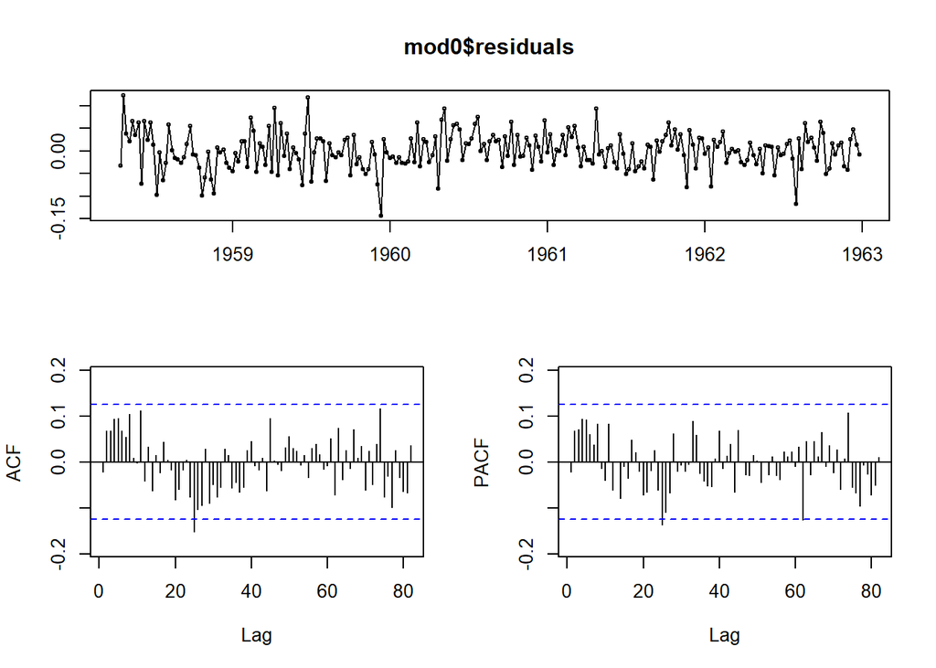

```r
forecast::tsdisplay(mod0$residuals)
```

```r
mod0
```

```
##
## Time series regression with "ts" data:
## Start = 1958(16), End = 1962(52)
##
## Call:
## dynlm(formula = colgate_ts_train ~ L(crest_ts_train, 0:15) +
##     L(colgate_ts_train, 1))
##
## Coefficients:
##               (Intercept)   L(crest_ts_train, 0:15)0
##                  0.300010                  -0.476237
##  L(crest_ts_train, 0:15)1   L(crest_ts_train, 0:15)2
##                  0.103782                  -0.016133
##  L(crest_ts_train, 0:15)3   L(crest_ts_train, 0:15)4
##                 -0.012846                   0.102357
##  L(crest_ts_train, 0:15)5   L(crest_ts_train, 0:15)6
##                 -0.054853                   0.084818
##  L(crest_ts_train, 0:15)7   L(crest_ts_train, 0:15)8
##                 -0.000164                  -0.020596
##  L(crest_ts_train, 0:15)9  L(crest_ts_train, 0:15)10
##                 -0.009384                  -0.040676
## L(crest_ts_train, 0:15)11  L(crest_ts_train, 0:15)12
##                  0.046659                  -0.004975
## L(crest_ts_train, 0:15)13  L(crest_ts_train, 0:15)14
##                  0.074017                   0.004486
## L(crest_ts_train, 0:15)15     L(colgate_ts_train, 1)
##                 -0.052888                   0.261096
```

```r
summary(mod0)
```

```
##
## Time series regression with "ts" data:
## Start = 1958(16), End = 1962(52)
##
## Call:
## dynlm(formula = colgate_ts_train ~ L(crest_ts_train, 0:15) +
##     L(colgate_ts_train, 1))
##
## Residuals:
##       Min        1Q    Median        3Q       Max
## -0.143770 -0.026679 -0.000066  0.025638  0.122197
##
## Coefficients:
##                            Estimate Std. Error t value Pr(>|t|)
## (Intercept)                0.300010   0.026671  11.249  < 2e-16 ***
## L(crest_ts_train, 0:15)0  -0.476237   0.059643  -7.985 6.99e-14 ***
## L(crest_ts_train, 0:15)1   0.103782   0.069020   1.504    0.134
## L(crest_ts_train, 0:15)2  -0.016133   0.064174  -0.251    0.802
## L(crest_ts_train, 0:15)3  -0.012846   0.065718  -0.195    0.845
## L(crest_ts_train, 0:15)4   0.102357   0.065903   1.553    0.122
## L(crest_ts_train, 0:15)5  -0.054853   0.066400  -0.826    0.410
## L(crest_ts_train, 0:15)6   0.084818   0.066258   1.280    0.202
## L(crest_ts_train, 0:15)7  -0.000164   0.066700  -0.002    0.998
## L(crest_ts_train, 0:15)8  -0.020596   0.066494  -0.310    0.757
## L(crest_ts_train, 0:15)9  -0.009384   0.067088  -0.140    0.889
## L(crest_ts_train, 0:15)10 -0.040676   0.067273  -0.605    0.546
## L(crest_ts_train, 0:15)11  0.046659   0.067083   0.696    0.487
## L(crest_ts_train, 0:15)12 -0.004975   0.066975  -0.074    0.941
## L(crest_ts_train, 0:15)13  0.074016   0.065300   1.133    0.258
## L(crest_ts_train, 0:15)14  0.004486   0.064196   0.070    0.944
## L(crest_ts_train, 0:15)15 -0.052888   0.060961  -0.868    0.387
## L(colgate_ts_train, 1)     0.261096   0.063932   4.084 6.14e-05 ***
## ---
## Signif. codes:  0 '***' 0.001 '**' 0.01 '*' 0.05 '.' 0.1 ' ' 1
##
## Residual standard error: 0.04211 on 227 degrees of freedom
## Multiple R-squared:  0.6006, Adjusted R-squared:  0.5707
## F-statistic: 20.08 on 17 and 227 DF,  p-value: < 2.2e-16
```

```r
mod0$coef
```

```
##               (Intercept)  L(crest_ts_train, 0:15)0  L(crest_ts_train, 0:15)1
##              0.3000098959             -0.4762371944              0.1037821664
##  L(crest_ts_train, 0:15)2  L(crest_ts_train, 0:15)3  L(crest_ts_train, 0:15)4
##             -0.0161326038             -0.0128463279              0.1023566709
##  L(crest_ts_train, 0:15)5  L(crest_ts_train, 0:15)6  L(crest_ts_train, 0:15)7
##             -0.0548530236              0.0848181259             -0.0001639901
##  L(crest_ts_train, 0:15)8  L(crest_ts_train, 0:15)9 L(crest_ts_train, 0:15)10
##             -0.0205957841             -0.0093836087             -0.0406755763
## L(crest_ts_train, 0:15)11 L(crest_ts_train, 0:15)12 L(crest_ts_train, 0:15)13
##              0.0466590524             -0.0049751967              0.0740165036
## L(crest_ts_train, 0:15)14 L(crest_ts_train, 0:15)15    L(colgate_ts_train, 1)
##              0.0044858128             -0.0528876765              0.2610963110
```

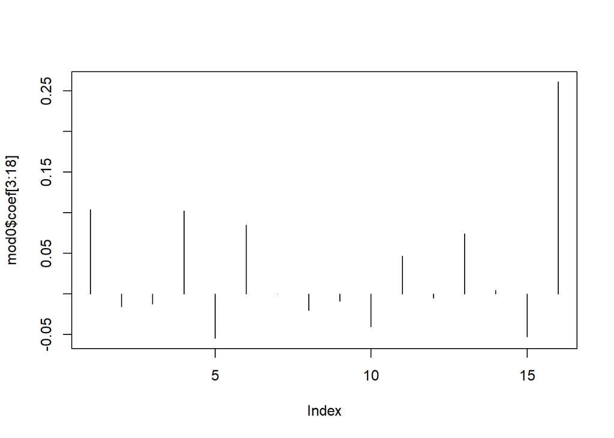

```r
plot(mod0$coef[3:18],type="h")
```

```r
mod <- arimax(colgate_ts_train,
              order=c(1,0,0),
              include.mean=TRUE,
              xtransf=crest_ts_train,

              transfer=list(c(0,15)),
              method="ML")

mod
```

```
##
## Call:
## arimax(x = colgate_ts_train, order = c(1, 0, 0), include.mean = TRUE, method = "ML",
##     xtransf = crest_ts_train, transfer = list(c(0, 15)))
##
## Coefficients:
##          ar1  intercept   T1-MA0   T1-MA1   T1-MA2   T1-MA3  T1-MA4   T1-MA5
##       0.2615     0.4057  -0.4749  -0.0206  -0.0216  -0.0181  0.0965  -0.0290
## s.e.  0.0617     0.0083   0.0573   0.0571   0.0594   0.0617  0.0624   0.0628
##       T1-MA6  T1-MA7   T1-MA8   T1-MA9  T1-MA10  T1-MA11  T1-MA12  T1-MA13
##       0.0763  0.0209  -0.0158  -0.0131  -0.0435   0.0353   0.0050   0.0722
## s.e.  0.0631  0.0633   0.0633   0.0639   0.0637   0.0632   0.0626   0.0601
##       T1-MA14  T1-MA15
##        0.0212  -0.0586
## s.e.   0.0588   0.0587
##
## sigma^2 estimated as 0.001643:  log likelihood = 437.73,  aic = -839.46
```

```r
mod$coef
```

```
##          ar1    intercept       T1-MA0       T1-MA1       T1-MA2       T1-MA3
##  0.261502388  0.405673287 -0.474944921 -0.020617081 -0.021601741 -0.018124641
##       T1-MA4       T1-MA5       T1-MA6       T1-MA7       T1-MA8       T1-MA9
##  0.096498667 -0.028958915  0.076348171  0.020927867 -0.015840724 -0.013149184
##      T1-MA10      T1-MA11      T1-MA12      T1-MA13      T1-MA14      T1-MA15
## -0.043519231  0.035347122  0.005028912  0.072218527  0.021158051 -0.058641125
```

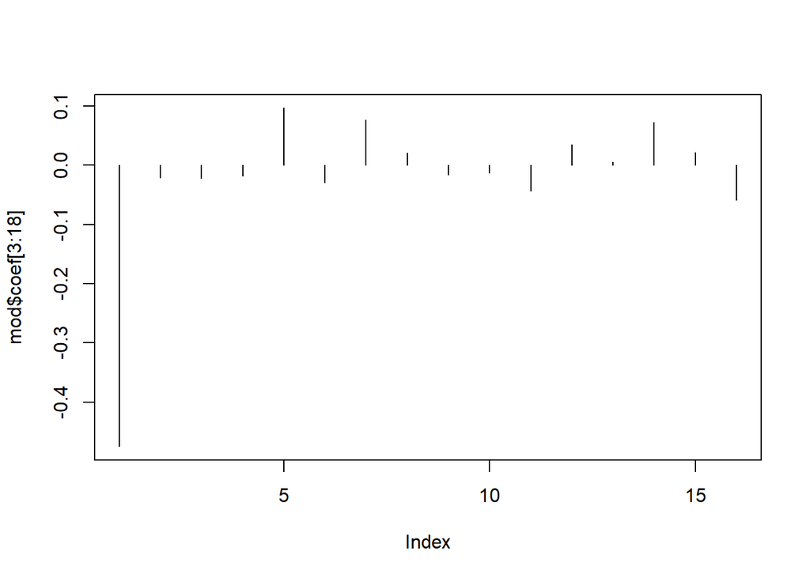

```r
plot(mod$coef[3:18],type="h")
```

Divides el coefficient entre el SE:

- If coeff/SE > 1, then fixed = NA
- If coeff/SE < 1, then fixed = 0

```r
mod <- arimax(colgate_ts_train,
              order=c(1,0,1),
              include.mean=FALSE,
              #fixed=c(NA,NA, 0, NA, NA, 0),
              xtransf=crest_ts_train,
              xreg = crest_ts_train,
              transfer=list(c(0,0)),
              method="ML")

summary(mod)
```

```
##
## Call:
## arimax(x = colgate_ts_train, order = c(1, 0, 1), xreg = crest_ts_train, include.mean = FALSE,
##     method = "ML", xtransf = crest_ts_train, transfer = list(c(0, 0)))
##
## Coefficients:
##          ar1      ma1       xreg    T1-MA0
##       0.9999  -0.8343    -0.4499    -0.043
## s.e.  0.0002   0.0362  1976.3677  1976.368
##
## sigma^2 estimated as 0.001776:  log likelihood = 451.38,  aic = -894.77
##
## Training set error measures:
##                         ME       RMSE        MAE       MPE     MAPE      MASE
## Training set -0.0001944331 0.04214801 0.03272845 -1.732483 10.87406 0.7013045
##                    ACF1
## Training set 0.08417646
```

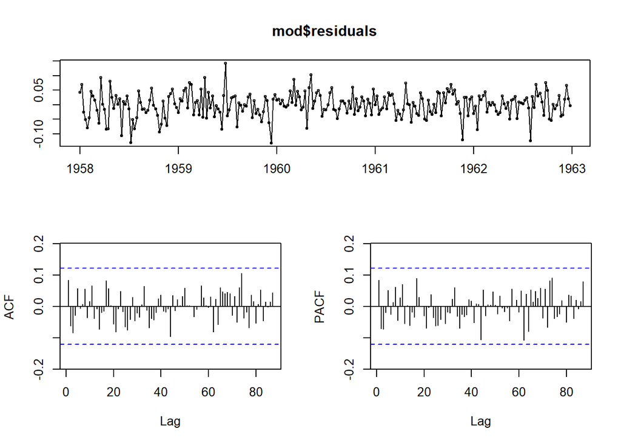

```r
forecast::tsdisplay(mod$residuals)
```

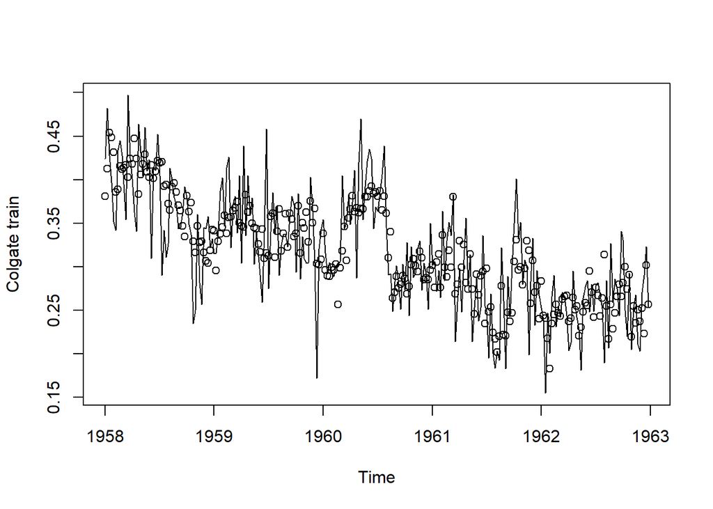

```r
plot(colgate_ts_train,ylab='Colgate train')
points(fitted(mod))
```

```r
ff <- predict(mod, newxreg = crest_ts_test, n.ahead = 16)
ff
```

```
## $pred
## Time Series:
## Start = c(1963, 1)
## End = c(1963, 16)
## Frequency = 52
##           Series 1  Series 2
## 1963.000 0.2822143 0.4433269
## 1963.019 0.2713657 0.4422427
## 1963.038 0.2659157 0.4416749
## 1963.058 0.2564168 0.4407199
## 1963.077 0.2667126 0.4416581
## 1963.096 0.3129986 0.4460385
## 1963.115 0.2855046 0.4433623
## 1963.135 0.2904018 0.4437842
## 1963.154 0.2503112 0.4399033
## 1963.173 0.2448612 0.4393355
## 1963.192 0.2956460 0.4441463
## 1963.212 0.2474577 0.4394908
## 1963.231 0.2802473 0.4425805
## 1963.250 0.2837950 0.4428733
## 1963.269 0.2468536 0.4392936
## 1963.288 0.2868413 0.4430717
##
## $se
## Time Series:
## Start = c(1963, 1)
## End = c(1963, 16)
## Frequency = 52
##  [1] 0.04214801 0.04272161 0.04328749 0.04384594 0.04439725 0.04494167
##  [7] 0.04547945 0.04601084 0.04653603 0.04705525 0.04756869 0.04807654
## [13] 0.04857896 0.04907613 0.04956820 0.05005533
```

```r
as.data.frame(ff)
```

| pred.Series.1 | pred.Series.2 | se |
| --- | --- | --- |
| 0.2822143 | 0.4433269 | 0.04214801 |
| 0.2713657 | 0.4422427 | 0.04272161 |
| 0.2659157 | 0.4416749 | 0.04328749 |
| 0.2564168 | 0.4407199 | 0.04384594 |
| 0.2667126 | 0.4416581 | 0.04439725 |
| 0.3129986 | 0.4460385 | 0.04494167 |
| 0.2855046 | 0.4433623 | 0.04547945 |
| 0.2904018 | 0.4437842 | 0.04601084 |
| 0.2503112 | 0.4399033 | 0.04653603 |
| 0.2448612 | 0.4393355 | 0.04705525 |

[output cut: 6 more lines]

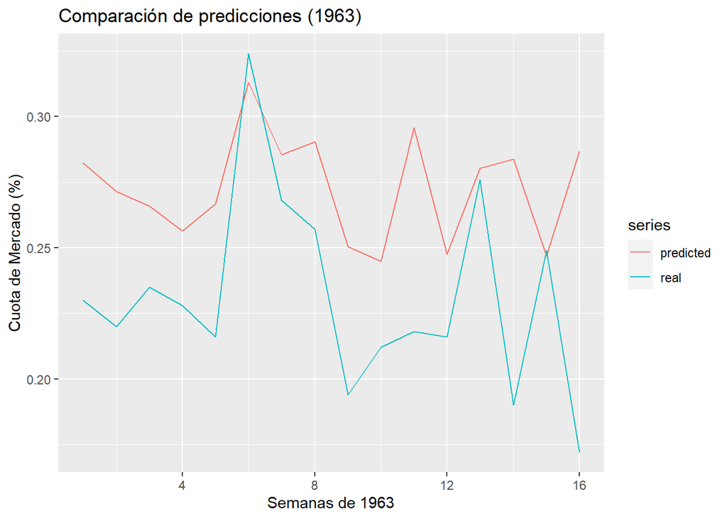

```r
col_compare2 <- as.data.frame(ff)['pred.Series.1']
col_compare2 <- cbind(col_compare2, as.data.frame(colgate_ts_test))
colnames(col_compare2) <- c('predicted', 'real')

col_compare2 <- ts(col_compare2)
autoplot(col_compare2) +
  ggtitle("Comparación de predicciones (1963)")+
  labs(y = "Cuota de Mercado (%)", x = 'Semanas de 1963')
```